# A demo on how to make phylogenetic trees using iNaturalist observations

Author

Maxime Dahirel

Published

2025-05-01

Since 2023, I’ve been making phylogenetic trees following each [#InverteFest](http://www.metrofieldguide.com/invertefest/) event, using the observations from the corresponding [iNaturalist projects](https://www.inaturalist.org/search?q=invertefest&source%5B%5D=projects). Originally, I wrote some [ad hoc code](https://github.com/mdahirel/invertefest_tree) for one session that I then had to manually modify, fairly deeply, for each session, which is less than ideal. For the last session of 2024, I started to rework that code to make it more flexible, with an eye on adding more functionalities in the future.

**Code: load packages and custom functions**

```r
library(tidyverse)
library(assertthat)
library(httr2)
library(ape)
library(rotl)
library(ggtree)
library(ggtext)
library(rphylopic)
library(showtext)
library(here)

source(here("R","get_inat.R"))
```

# Loading iNat observations

The custom-made `get_inat` function[^1] uses the `httr2` package to query the iNat API, and then formats back the output in an R tidy manner. It can currently extract taxon names from a specific project, a specific user, or both. It will be possible to extract more than taxon names in the future, and to restrict to a target taxon.

**Warning**

Note that the function currently enforces the recommended-by-iNat maximum of **10k results per request**. If a request would lead to more than 10000 results, only the 10000 more recent would be returned. I might later add ways to work around that (e.g. multiple requests stitched together) if I personally run into a use case that needs it (backup of my own iNat obs, for instance, but that’s currently way under 10k).

**Code: query API to get iNat results**

```r
inat_names <- get_inat(project_id="invertefest-april-2025")
```

```r
head(inat_names)
```

```
# A tibble: 6 × 4
  name                      id iconic_taxon_name iconic_taxon_id
  <chr>                  <int> <chr>                       <int>
1 Agelenopsis            82116 Arachnida                   47119
2 Glycythyma leonina    209615 Insecta                     47158
3 Brachycera             48091 Insecta                     47158
4 Erebus caprimulgus    120521 Insecta                     47158
5 Leptomantella         603576 Insecta                     47158
6 Drepanosticta gazella 561093 Insecta                     47158
```

# Generating tree data from the Open Tree of Life

Now that we have our taxon names, we are going to use the [`rotl`](https://docs.ropensci.org/rotl/) package to interact with the [Open Tree of Life](http://opentreeoflife.org/):  
- to get Open Tree Taxonomy IDs from our taxon names  
- then to get a subtree of the Open Tree of Life from these IDs

But first: because different areas in the Tree of Life are regulated by different taxonomic codes, a same name can be perfectly valid for e.g. a plant and an animal at the same time. To limit the risk of ambiguous matches, OTOL allows you to attempt to match a name only within a specific subset of the Tree of Life, or “context” (e.g. only animals).

So we first use the “iconic taxon” data of iNat to help `rotl` knows which context matches each name…

**Code: get name context**

```r
inat_context <- inat_names |>
  mutate(
    ott_context = case_when(
      iconic_taxon_name=="Animalia"~"Animals", # careful: this iconic name is all animals *except* the ones under an other iconic name already
      iconic_taxon_name=="Amphibia"~"Amphibians",
      iconic_taxon_name=="Aves"~"Birds",
      iconic_taxon_name=="Mammalia"~"Mammals",
      iconic_taxon_name=="Reptilia"~"Tetrapods",
      iconic_taxon_name=="Actinopterygii"~"Vertebrates",

      iconic_taxon_name=="Insecta"~"Insects", # use arthropod context to be safe re: trt of entognaths? tbd
      iconic_taxon_name=="Arachnida"~"Arachnids",

      iconic_taxon_name=="Mollusca"~"Molluscs",

      iconic_taxon_name=="Chromista"~"All life",

      iconic_taxon_name=="Protozoa"~"All life",

      iconic_taxon_name=="Fungi"~"Fungi", # all life context to be safe re: lichens? check and tbd

      iconic_taxon_name=="Plantae"~"Land plants",

      iconic_taxon_name=="unknown"~"All life",
      TRUE~"All life")
  ) |>
  select(iconic_taxon_name,ott_context,name) |>
  distinct() # no need for duplicates
```

```r
head(inat_context)
```

```
# A tibble: 6 × 3
  iconic_taxon_name ott_context name
  <chr>             <chr>       <chr>
1 Arachnida         Arachnids   Agelenopsis
2 Insecta           Insects     Glycythyma leonina
3 Insecta           Insects     Brachycera
4 Insecta           Insects     Erebus caprimulgus
5 Insecta           Insects     Leptomantella
6 Insecta           Insects     Drepanosticta gazella
```

… before actually asking for the info (beware: this may take a while. Getting the matched OTT IDs is fairly fast, but making sure each is valid and in the Open Tree can be slow).

**Code: get OTT IDs**

```r
inat_ott <- inat_context |>
  group_by(ott_context) |>
  nest() |>
  mutate(
    resolved_names=map2(
      .x=data,
      .y=ott_context,
      .f=function(.x,.y){
        tnrs_match_names(.x$name,context_name=.y) |>
          filter(!is.na(ott_id)) |>
          mutate(in_tree=is_in_tree(ott_id))
        }
      )
    ) |>
# takes a while:
# simply filtering out flags likely to signal "not in tree" status (eg incertae sedis) would work faster, but may be more approximate/trial-and-error:
   mutate(filtered_names = map(
     .x = resolved_names,
     .f= ~.x |>
       filter(in_tree==TRUE & score > 0.9) # can adjust score
   )
   )

ott_cleaned <- inat_ott |>
  ungroup() |>
  select(filtered_names) |>
  unnest(filtered_names) |>
  select(unique_name,search_string,ott_id) |>
  distinct()
```

```r
head(ott_cleaned)
```

```
# A tibble: 6 × 3
  unique_name          search_string         ott_id
  <chr>                <chr>                  <int>
1 Agelenopsis          agelenopsis           725328
2 Pholcidae            pholcidae             395536
3 Clubiona             clubiona              514831
4 Heteropoda strasseni heteropoda strasseni 3550815
5 Mimetidae            mimetidae             608424
6 Orsinome vethi       orsinome vethi       3572859
```

**Taxons lost in processing**

Not all names are successfully matched by `tnrs_match_names()`, some are matched but matches are low-quality and likely wrong, some are matched but the taxon is not in the synthetic tree and needs to be removed to avoid errors when generating our subtree. In this example, we still get 1649 OTT IDs out of 1860 unique names in the input, which is good enough for now.

**Code: get the tree from OTOL**

```r
tol_induced_subtree(
  ott_ids = unique(ott_cleaned$ott_id),
  label_format = "name", file = here("tree_data", "tree.newick")
)

my_tree <- ape::read.tree(here("tree_data", "tree.newick"))
```

We save the tree in Newick format to `file`, and then reimport it immediately. We actually don’t need to do that to get the tree, we could directly get the tree as a `phylo` object, by letting the `file` argument empty. But doing that tends to collapse a lot of internal nodes[^2] (which contains the clade names), and these can be very useful to annotate the tree.

# Plotting the tree

We use the [`ggtree`](https://github.com/YuLab-SMU/ggtree) package to plot and annotate the tree. We can use many types of annotations. We’re going to combine colour highlighting of major clades and [PhyloPic](https://www.phylopic.org/) images of some iconic groups, courtesy of the [`rphylopic`](https://rphylopic.palaeoverse.org/) package. We also make sure that the silhouettes are properly credited on the plot.

**Code: prepare tree annotations**

```r
d1 <- data.frame(
  node = c(
    length(my_tree$tip.label) + which(my_tree$node.label == "Insecta"),
    length(my_tree$tip.label) + which(my_tree$node.label == "Malacostraca"),
    length(my_tree$tip.label) + which(my_tree$node.label == "Araneae"),
    length(my_tree$tip.label) + which(my_tree$node.label == "Mollusca"),
    length(my_tree$tip.label) + which(my_tree$node.label == "Myriapoda")
  ),
  taxon = c("Insects", "Malacostracans","Spiders", "Molluscs", "Myriapods")
)


d2 <- data.frame(
  node = c(
    length(my_tree$tip.label) + which(my_tree$node.label == "Diptera"),
    length(my_tree$tip.label) + which(my_tree$node.label == "Hymenoptera"),
    length(my_tree$tip.label) + which(my_tree$node.label == "Coleoptera"),
    length(my_tree$tip.label) + which(my_tree$node.label == "Lepidoptera"),
    length(my_tree$tip.label) + which(my_tree$node.label == "Orthoptera"),
    length(my_tree$tip.label) + which(my_tree$node.label == "Araneae"),
    length(my_tree$tip.label) + which(my_tree$node.label == "Gastropoda"),
    length(my_tree$tip.label) + which(my_tree$node.label == "Odonata"),
    length(my_tree$tip.label) + which(my_tree$node.label == "Hemiptera"),
    length(my_tree$tip.label) + which(my_tree$node.label == "Myriapoda"),
    length(my_tree$tip.label) + which(my_tree$node.label == "Cnidaria")
  ),
  taxon = c(
    "Diptera", "Hymenoptera", "Coleoptera", "Lepidoptera",
    "Orthoptera", "Araneae", "Gastropoda", "Odonata", "Hemiptera", "Myriapoda","Cnidaria"
  ),
  image = c(
    get_uuid(name = "Drosophila americana", n = 1),
    get_uuid(name = "Vespula", n = 1),
    get_uuid(name = "Carabus", n = 1),
    get_uuid(name = "Papilio", n = 1),
    get_uuid(name = "Acrididae", n = 1),
    get_uuid(name = "Araneus", n = 1),
    get_uuid(name = "Helix aspersa", n = 1),
    get_uuid(name = "Sympetrum", n = 1),
    get_uuid(name = "Lycorma delicatula", n = 1),
    get_uuid(name = "Lithobius forficatus", n = 1),
    get_uuid(name = "Actinia equina", n = 1)
  )
) |>
  mutate(contributor = map(.x=image,.f=~.x |> get_attribution() |> pluck("images",.x,"attribution")),
         license = map(.x=image,.f=~.x |> get_attribution() |> pluck("images",.x,"license_abbr"))
  ) |>
  mutate(attr = paste0(taxon,": ", contributor, " (", license,")")) |>
  arrange(taxon)

phylopic_credit <- paste0("Animal silhouettes are from **phylopic.org**. ",paste(d2$attr,collapse="; "),".")

figure_author <- "Data visualisation by **Maxime Dahirel**, underlying code: **github.com/mdahirel/inat_tree**"

#(tips are counted as nodes for `ggtree` purposes, that's why we add the number of tips to get the correct node values)
```

**Code: create the tree**

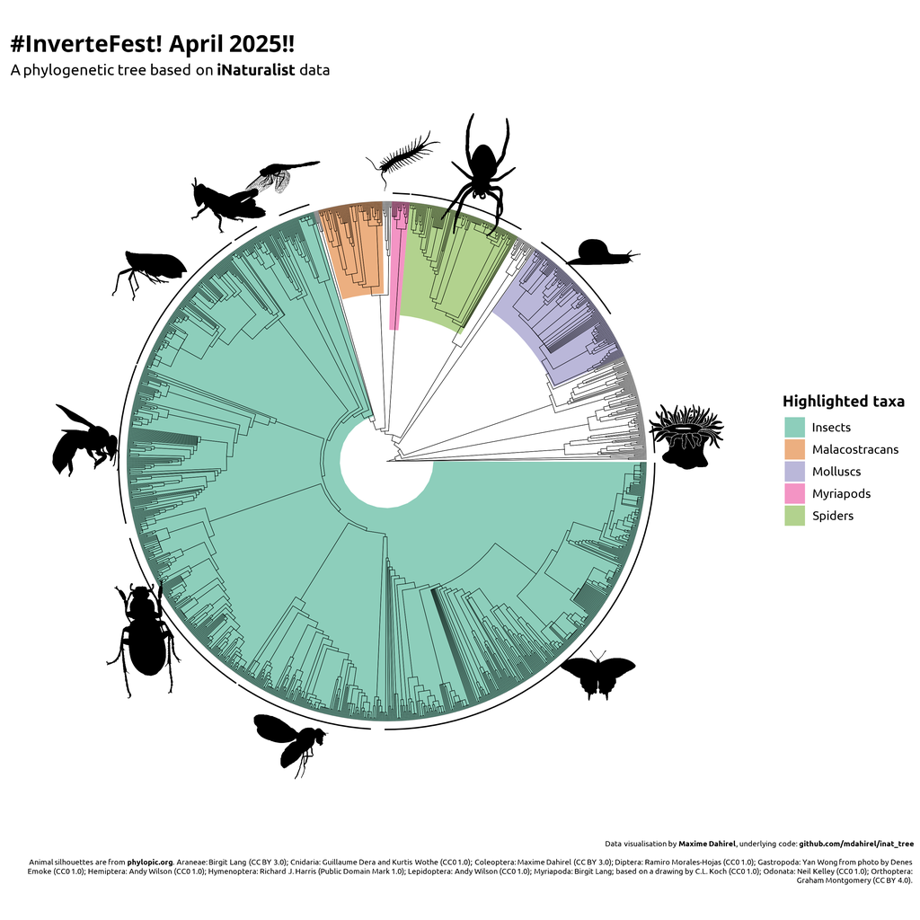

```r
font_add_google(name="Open Sans",family="Open Sans")
font_add_google(name="Ubuntu",family="Ubuntu")

showtext_auto()

tree_line_width <- 0.15

p <- ggtree(my_tree, layout = "circular", size=tree_line_width) +
  geom_highlight(data = d1, aes(node = node, fill = taxon)) +
  geom_tree(size=tree_line_width) +
  geom_cladelab(
    data = d2,
    mapping = aes(node = node, label = taxon, image = image), imagesize = 0.1,
    geom = "phylopic", imagecolour = "black", offset = 1, offset.text = 10, alpha = 1
  ) +
  scale_fill_brewer(name= "**Highlighted taxa**",palette = "Dark2") +
  labs(
    title="**#InverteFest! April 2025!!**",
    subtitle="A phylogenetic tree based on **iNaturalist** data",
    caption = paste0(figure_author,"<br/><br/>",phylopic_credit)
  )+
  theme(text=element_text(family = "Ubuntu", size = 12),
        plot.title=element_markdown(family = "Open Sans", size = 18),
        plot.subtitle=element_markdown(family = "Ubuntu"),
        legend.title=element_markdown(family = "Ubuntu"),
        legend.justification = "right",
        plot.caption = element_textbox_simple(family = "Ubuntu",size=6, halign=1),
        plot.caption.position = "plot"
        )

ggsave(here("tree_plots","tree.pdf"), plot = p, device=cairo_pdf)

showtext_opts(dpi = 300)
ggsave(here("tree_plots","tree.png"), plot = p)
knitr::include_graphics(here("tree_plots","tree.png"))
```

**Note**

In some cases, you may notice that there are fewer tips in the tree than we have “valid” OTT IDs (here: 1356 vs 1649). This is because higher-level IDs will end up as internal nodes if there exists another observation from the same taxon but with a more precise ID (for instance, for a set of two observations, one identified as *Cepaea* sp. and one as *Cepaea nemoralis*, we would end up with only one tip in the tree, *Cepaea nemoralis*, with *Cepaea* as an internal node).

## Footnotes

[^1]: see `R/get_inat.R` in code repository
[^2]: It will collapse an internal node if there is no branching there. For instance, if all your insects in the tree are Pterygota (no never-winged insects such as silverfish, for instance), then the Insecta node would be removed since there would be no branching at that node, which is bad if you have downstream annotations explicitly relying on “Insecta”.